# 4. Supervised multiblock analysis

```r
library(multiblock)
```

# Supervised methods

The following supervised methods are available in the *multiblock* package (function names in parentheses):

- MB-PLS - Multiblock Partial Least Squares (*mbpls*)
- SO-PLS - Sequential and Orthogonalised PLS (*sopls*)
- PO-PLS - Parallel and Orthogonalised PLS (*popls*)
- ROSA - Response Oriented Sequential Alternation (*rosa*)
- mbRDA - Multiblock Redundancy Analysis (*mbrda*)

The following sections will describe how to format your data for analysis and invoke all methods from the list above.

# Formatting data for multiblock analyses

```r
# Random data
n <- 30; p <- 90
X <- matrix(rnorm(n*p), nrow=n)
y <- X %*% rnorm(p) + 10

# Split X into three blocks in a named list
ABC <- list(A = X[,1:20], B = X[,21:50], C = X[,51:90], y = y)

# Model using names of blocks (see below for full SO-PLS example)
so.abc <- sopls(y ~ A + B + C, data = ABC, ncomp = c(4,3,4))
```

# Multiblock Partial Least Squares - MB-PLS

Multiblock PLS is presented briefly using the *potato* data.

## Modelling

A multi-response two-block MB-PLS model with up to 10 components in total is cross-validated with 10 random segments.

```r
data(potato)
mb <- mbpls(potato[c('Chemical','Compression')], potato[['Sensory']], ncomp = 10,
            max_comps=10, validation="CV", segments=10)
print(mb)
```

```
#> Multiblock PLS
#>
#> Call:
#> mbpls(X = potato[c("Chemical", "Compression")], Y = potato[["Sensory"]],     ncomp = 10, max_comps = 10, validation = "CV", segments = 10)
```

## Summaries and plotting

MB-PLS is implemented as a block-wise weighted concatenated ordinary PLSR. Therefore, all methods available for *plsr* are available for the global part of the MB-PL. In addition one can extrac *blockScores* and *blockLoadings*.

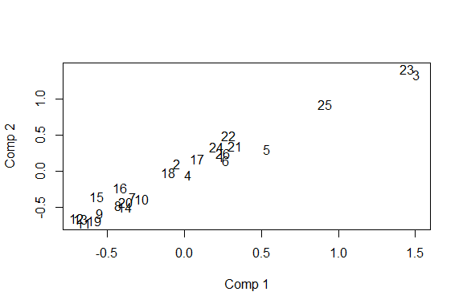

```r
Tb1 <- scores(mb, block=1)
plot(Tb1, labels = "names")
```

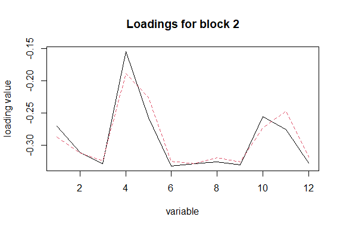

```r
Pb2 <- loadings(mb, block=2)
plot(Pb2, main = 'Loadings for block 2')
```

# Sequential and orthogonalised PLS - SO-PLS

The following example uses the *potato* data to showcase some of the functions available for SO-PLS analyses.

## Modelling

A multi-response two-block SO-PLS model with up to 10 components in total is cross-validated with 10 random segments.

```r
# Load potato data and fit SO-PLS model
so.pot <- sopls(Sensory ~ Chemical + Compression, data=potato,
            ncomp=c(10,10), max_comps=10, validation="CV", segments=10)
print(so.pot)
```

```
#> Sequential and Orthogonalized Partial Least Squares, fitted with the PKPLS algorithm.
#> Cross-validated using 10 random segments.
#> Call:
#> sopls(formula = Sensory ~ Chemical + Compression, ncomp = c(10,     10), max_comps = 10, data = potato, validation = "CV", segments = 10)
```

```r
summary(so.pot)
```

```
#> Data:    X dimension: 26 0
#>  Y dimension: 26 9
#> Fit method: PKPLS
#> Number of components considered: 10
#>
#> VALIDATION: RMSEP
#> Cross-validated using 10 random segments.
#>    0,0     0,1     0,2     0,3     0,4     0,5     0,6     0,7     0,8     0,9
#> 1.1472  0.9974  1.1034  0.9942  1.0159  1.1523  1.0857  1.1834  1.2494  1.3022
#>   0,10     1,0     1,1     1,2     1,3     1,4     1,5     1,6     1,7     1,8
#> 1.2690  0.9058  0.8860  0.9779  0.9029  0.8942  0.9320  0.9441  1.0542  1.1243
#>    1,9     2,0     2,1     2,2     2,3     2,4     2,5     2,6     2,7     2,8
#> 1.1369  0.8077  0.7023  0.7124  0.7737  0.8072  0.8651  0.8511  0.9742  1.0048
#>    3,0     3,1     3,2     3,3     3,4     3,5     3,6     3,7     4,0     4,1
#> 0.7439  0.7275  0.7111  0.7716  0.8322  0.8846  0.8893  0.9793  0.7494  0.7165
#>    4,2     4,3     4,4     4,5     4,6     5,0     5,1     5,2     5,3     5,4
#> 0.7272  0.7748  0.8135  0.9157  0.9001  0.7752  0.7491  0.7593  0.8494  0.9693
#>    5,5     6,0     6,1     6,2     6,3     6,4     7,0     7,1     7,2     7,3
#> 1.0306  0.8504  0.8438  0.8198  0.9304  1.0222  0.8997  0.8910  0.8418  0.9632
#>    8,0     8,1     8,2     9,0     9,1    10,0
#> 1.0062  1.0033  0.9511  1.0682  1.0557  1.6371
#>
#> TRAINING: % variance explained
#>         0,0    0,1    0,2    0,3    0,4    0,5    0,6    0,7    0,8    0,9
#> X         0  45.87  55.51  62.90  66.46  67.73  74.95  78.26  79.85  82.39
#> ref       0  42.19  54.73  65.01  66.85  73.96  74.10  74.44  77.45  77.57
#> hard      0  39.11  41.97  42.23  43.80  50.95  54.87  56.78  59.50  74.53
#> firm      0  42.55  57.44  59.44  61.06  66.78  68.62  69.02  71.34  76.53
#> elas      0  38.64  65.31  73.51  75.63  77.23  79.25  81.19  83.71  86.57
#> adhes     0  16.13  18.11  26.71  26.74  29.70  42.07  44.57  46.47  46.54
#> grainy    0  23.21  43.78  62.23  64.02  67.18  67.72  69.83  74.79  74.79
#> mealy     0  35.35  41.99  57.36  58.84  67.17  70.33  73.21  77.77  78.88
#> moist     0  24.48  27.71  43.10  44.27  48.41  53.39  62.37  67.60  74.79
#> chewi     0  21.98  22.78  48.17  55.50  59.96  68.39  72.54  76.39  77.42
#>          0,10    1,0    1,1    1,2    1,3    1,4    1,5    1,6    1,7    1,8
#> X       83.18  34.20  64.12  71.71  76.24  78.20  79.49  83.37  84.42  85.59
#> ref     77.57  55.79  64.00  64.25  73.75  77.39  79.53  80.42  80.50  80.96
#> hard    75.43  24.10  41.42  44.05  44.07  44.09  47.61  53.70  53.86  62.46
#> firm    79.31  42.73  54.16  58.42  62.05  63.55  64.91  70.85  70.91  70.93
#> elas    88.14  53.24  59.32  63.95  71.43  74.51  75.33  77.16  78.86  78.88
```

[output cut: 45 more lines]

```
#> grainy  92.38  91.29  91.41  93.80  94.06  94.27  91.78  91.89  94.29  94.34
#> mealy   94.83  90.67  91.24  91.36  94.83  95.44  92.38  92.87  92.98  94.77
#> moist   84.08  82.80  82.90  82.93  85.65  85.67  85.12  85.26  85.29  86.55
#> chewi   86.50  84.60  84.72  86.16  86.49  87.50  86.05  86.22  87.61  87.62
#>           8,0    8,1    8,2    9,0    9,1   10,0
#> X       82.82  88.16  95.96  85.49  90.21  87.08
#> ref     90.82  94.67  94.93  91.52  94.42  91.79
#> hard    52.73  59.90  60.33  52.75  63.37  52.92
#> firm    71.26  80.42  80.49  71.81  80.88  71.82
#> elas    73.78  80.71  81.41  75.22  80.15  76.14
#> adhes   68.88  68.89  69.28  71.74  72.73  74.17
#> grainy  91.80  93.21  94.39  91.99  92.91  92.43
#> mealy   93.59  94.05  94.31  93.75  93.98  93.83
#> moist   86.40  86.60  87.34  87.11  88.40  87.14
#> chewi   87.11  88.40  88.43  87.27  89.53  87.28
```

## Måge plot

Full Måge plot for all combinations of components for all blocks. This can be used for a global search for the best fitting cross-validated model.

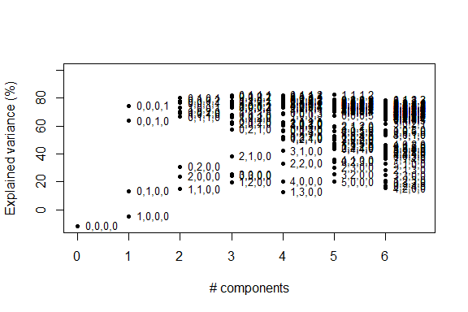

```r
# Load Wine data and model with SO-PLS
data(wine)
ncomp <- unlist(lapply(wine, ncol))[-5]
so.wine <- sopls(`Global quality` ~ ., data=wine, ncomp=ncomp,
             max_comps=6, validation="CV", segments=10)
maage(so.wine)
```

A sequential Måge plot can be used for a sequential search for the optimal model.

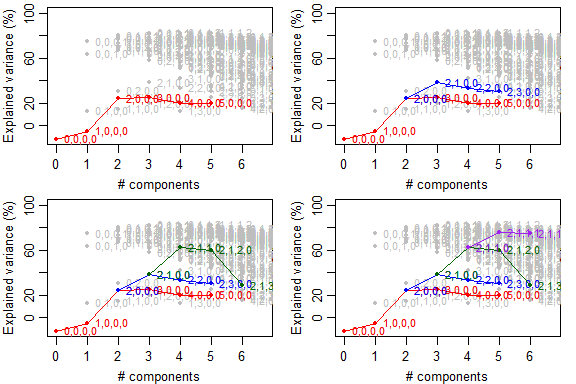

```r
# Sequential search for optimal number of components per block
old.par <- par(mfrow=c(2,2), mar=c(3,3,0.5,1), mgp=c(2,0.7,0))
maageSeq(so.wine)
maageSeq(so.wine, 2)
maageSeq(so.wine, c(2,1))
maageSeq(so.wine, c(2,1,1))
```

```r
par(old.par)
```

## Loadings

One set of loadings is printed and two sets are plotted to show how to select specific components from specific blocks.

```r
# Display loadings up to four components for first block
loadings(so.pot, ncomp = c(4,0), block = 1)
```

```
#>
#> Loadings:
#>              1,0    2,0    3,0    4,0
#> ChemicalPEU   0.645 -3.672  1.197  2.277
#> ChemicalSta. -4.542 -0.975 -0.984 -0.678
#> ChemicalTotN  0.478 -1.848  3.046 -1.613
#> ChemicalPhy. -3.970        -1.445  0.948
#> ChemicalCa   -1.365 -0.982  1.804 -1.190
#> ChemicalMg   -4.009 -0.280        -2.344
#> ChemicalNa   -3.066 -2.488  0.669  1.616
#> ChemicalK    -0.186 -0.255 -4.161  0.149
#> ChemicalHi.1 -4.493  2.113         0.344
#> ChemicalHi.2 -4.099  2.656 -0.739  0.488
#> ChemicalHi.3 -4.382  2.270 -0.259  0.398
#> ChemicalHi.4  3.000  0.732 -2.855
#> ChemicalHi.5 -4.419  2.023 -0.177  0.372
#> ChemicalHi.6  1.580  2.266 -3.570  0.571
#>
#>                    1,0    2,0    3,0    4,0
#> SS loadings    151.624 51.586 56.326 19.671
#> Proportion Var  10.830  3.685  4.023  1.405
#> Cumulative Var  10.830 14.515 18.538 19.943
```

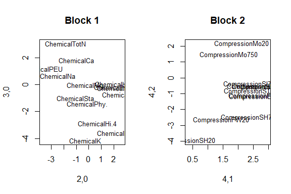

```r
# Plot loadings from block 1 and 2
old.par <- par("mfrow"); on.exit(par(old.par)); par(mfrow=c(1,2))
loadingplot(so.pot, ncomp = c(4,3), comps = c(2,3), block = 1, scatter = TRUE, main = "Block 1", labels = "names", cex = 0.8)
loadingplot(so.pot, ncomp = c(4,3), block = 2, scatter = TRUE, main = "Block 2", labels = "names", cex = 0.8)
```

```r
par(old.par)
```

## Scores

One set of scores is printed and two sets are plotted to show how to select specific components from specific blocks.

```r
# Display scores up to four components for first block
scores(so.pot, ncomp = c(4,0), block = 1)
```

```
#>             1,0         2,0          3,0         4,0
#> 1  -0.078379126 -0.15756558 -0.030150796 -0.08882899
#> 2   0.033599245  0.03345139 -0.264837392 -0.02082345
#> 3  -0.454087240 -0.50387774 -0.257625630  0.24822188
#> 4  -0.010144029  0.04409907  0.254739277  0.34206013
#> 5  -0.231320589  0.02813994  0.331647163 -0.15209020
#> 6  -0.100806072 -0.03203490  0.058511494 -0.07824489
#> 7   0.103759602  0.05587580  0.171495995  0.13245956
#> 8   0.142341829 -0.02952316  0.135315864  0.17766566
#> 9   0.160175421 -0.13395363  0.067732083 -0.34567441
#> 10  0.078862890 -0.20282246  0.065251294 -0.21205811
#> 11  0.200245777 -0.02882659  0.149667777 -0.08872396
#> 12  0.223602068 -0.07321286 -0.029748834 -0.22950703
#> 13  0.217320106 -0.26815383  0.096949900 -0.10070260
#> 14  0.142847549 -0.29951537  0.077252287  0.24996525
#> 15  0.213820293  0.17228886 -0.461863019 -0.11767172
#> 16  0.164964325  0.26005269 -0.323577542  0.10235857
#> 17  0.002967383  0.19480792 -0.246885356  0.19701818
#> 18  0.066258347  0.09356886 -0.228532411  0.20484080
#> 19  0.194213760 -0.01568159  0.132000297  0.14447620
#> 20  0.141301554 -0.07654188  0.049224760  0.26084474
#> 21 -0.129888279  0.04471652  0.038982799 -0.30565064
#> 22 -0.105636544  0.24576605 -0.030041538 -0.14535670
#> 23 -0.464479945 -0.11433433 -0.194275154 -0.06714686
#> 24 -0.082441922  0.22751259  0.233417343  0.13675311
#> 25 -0.325181587  0.44765983  0.208213841  0.07217114
#> 26 -0.103914818  0.08810440 -0.002864502 -0.31635566
#> attr(,"class")
#> [1] "scores"
```

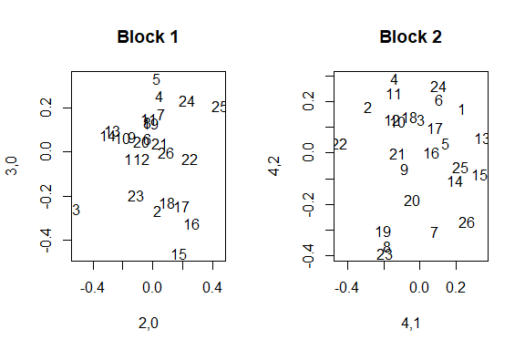

```r
# Plot scores from block 1 and 2
old.par <- par("mfrow"); on.exit(par(old.par)); par(mfrow=c(1,2))
scoreplot(so.pot, ncomp = c(4,3), comps = c(2,3), block = 1, main = "Block 1", labels = "names")
scoreplot(so.pot, ncomp = c(4,3), block = 2, main = "Block 2", labels = "names")
```

```r
par(old.par)
```

## Prediction

A three block model is fitted using a single response, 5 components and a subset of the data. The remaining data are used as test set for prediction.

```r
# Modify data to contain a single response
potato1 <- potato; potato1$Sensory <- potato1$Sensory[,1]
# Model 20 first objects with SO-PLS
so.pot20 <- sopls(Sensory ~ ., data = potato1[c(1:3,9)], ncomp = 5, subset = 1:20)
# Predict remaining objects
testset <- potato1[-(1:20),]; # testset$Sensory <- NULL
predict(so.pot20, testset, comps=c(2,1,2))
```

```
#> , , 1,0,0
#>
#>       Sensory
#> [1,] 3.922829
#> [2,] 3.801854
#> [3,] 6.409450
#> [4,] 2.960830
#> [5,] 4.433857
#> [6,] 3.223006
#>
#> , , 2,0,0
#>
#>       Sensory
#> [1,] 4.062985
#> [2,] 4.238679
#> [3,] 7.178207
#> [4,] 2.477011
#> [5,] 3.319856
#> [6,] 2.904183
#>
#> , , 2,1,0
#>
#>       Sensory
#> [1,] 4.169790
#> [2,] 4.471989
#> [3,] 7.282654
#> [4,] 2.426714
#> [5,] 3.273465
#> [6,] 2.898753
#>
#> , , 2,1,1
#>
#>         Sensory
#> [1,]  5.2214087
#> [2,]  5.1427034
#> [3,]  9.7861678
#> [4,] -0.7742392
#> [5,]  0.9645707
#> [6,]  2.2666501
#>
#> , , 2,1,2
#>
#>         Sensory
#> [1,]  5.4727706
#> [2,]  5.5669734
#> [3,] 11.3237645
#> [4,] -2.3105720
#> [5,]  0.2755925
#> [6,]  2.1649361
```

## Validation

Compute validation statistics; explained variance - R$^2$ and Root Mean Squared Error - RMSE(P/CV).

```r
# Cross-validation
R2(so.pot, ncomp = c(5,5))
```

```
#>        1,0        2,0        3,0        4,0        5,0        5,1        5,2
#> 0.29491711 0.43937819 0.52443674 0.51731500 0.48356727 0.51769239 0.50453909
#>        5,3        5,4        5,5
#> 0.37995426 0.19264375 0.08718665
```

```r
R2(so.pot, ncomp = c(5,5), individual = TRUE)
```

```
#>                1,0         2,0         3,0          4,0         5,0        5,1
#> ref     0.27825536  0.43256997  0.60854575  0.611650546  0.57962221  0.6410025
#> hard   -0.01534472 -0.19976337 -0.32629673 -0.629670315 -0.73850234 -0.5385860
#> firm    0.11456699  0.11663849  0.14175670 -0.005647699  0.07172321  0.2173452
#> elas    0.32922325  0.39196816  0.41920590  0.347290927  0.35236475  0.3873415
#> adhes  -0.04074410  0.02924686 -0.06114012  0.182892958  0.21626890  0.2398021
#> grainy  0.29892446  0.57657563  0.70726840  0.720648990  0.66998154  0.6426785
#> mealy   0.39732737  0.60662586  0.71089974  0.742956337  0.70442569  0.7074522
#> moist   0.42596297  0.55819542  0.60651611  0.602672591  0.54129827  0.5169465
#> chewi   0.38811017  0.58159817  0.56193588  0.643390275  0.56225915  0.5417198
#>               5,2         5,3         5,4         5,5
#> ref     0.6892006  0.64474046  0.66948387  0.69542145
#> hard   -0.6078491 -1.37218409 -2.90610544 -4.13991040
#> firm    0.2464953 -0.01322888 -0.26416572 -0.69554952
#> elas    0.4649800  0.43158366  0.45223779  0.09663100
#> adhes   0.1548038 -0.06098741 -0.71470005 -1.01032999
#> grainy  0.6653825  0.67115458  0.67261140  0.75006427
#> mealy   0.6671254  0.62578581  0.60276444  0.67661249
#> moist   0.3843608  0.12290559 -0.34127485 -0.48130723
#> chewi   0.4645314  0.35373420  0.06156931  0.07770671
```

```r
# Training
R2(so.pot, 'train', ncomp = c(5,5))
```

```
#>       1,0       2,0       3,0       4,0       5,0       5,1       5,2       5,3
#> 0.5321195 0.7063309 0.7545212 0.7890377 0.8065415 0.8303087 0.8419431 0.8603538
#>       5,4       5,5
#> 0.8735251 0.8807225
```

```r
# Test data
R2(so.pot20, newdata = testset, ncomp = c(2,1,2))
```

```
#>      1,0,0      2,0,0      2,1,0      2,1,1      2,1,2
#>  0.5217279  0.7330829  0.7208834  0.4494703 -0.2607736
```

```r
# Cross-validation
RMSEP(so.pot, ncomp = c(5,5))
```

```
#>       1,0       2,0       3,0       4,0       5,0       5,1       5,2       5,3
#> 0.9057837 0.8076801 0.7438897 0.7494390 0.7751956 0.7491460 0.7592925 0.8494079
#>       5,4       5,5
#> 0.9692527 1.0306125
```

```r
RMSEP(so.pot, ncomp = c(5,5), individual = TRUE)
```

```
#>              1,0       2,0       3,0       4,0       5,0       5,1       5,2
#> ref    1.4521251 1.2875627 1.0694309 1.0651814 1.1082357 1.0241368 0.9529110
#> hard   0.7409166 0.8053977 0.8468041 0.9386690 0.9695054 0.9120602 0.9323634
#> firm   0.8153675 0.8144132 0.8027508 0.8689574 0.8348612 0.7665856 0.7521744
#> elas   0.5987744 0.5700821 0.5571669 0.5906552 0.5883550 0.5722469 0.5347604
#> adhes  0.6238669 0.6025240 0.6299503 0.5527890 0.5413816 0.5331916 0.5622102
#> grainy 0.9124005 0.7090731 0.5895734 0.5759413 0.6259969 0.6513774 0.6303437
#> mealy  1.1918516 0.9629070 0.8254784 0.7783679 0.8346700 0.8303858 0.8857717
#> moist  0.8218611 0.7210138 0.6804434 0.6837585 0.7346723 0.7539214 0.8511216
#> chewi  0.6207792 0.5133308 0.5252540 0.4739114 0.5250602 0.5372372 0.5807210
#>              5,3       5,4       5,5
#> ref    1.0187910 0.9826720 0.9433262
#> hard   1.1324963 1.4532307 1.6670183
#> firm   0.8722266 0.9742660 1.1283161
#> elas   0.5511978 0.5410909 0.6948752
#> adhes  0.6299050 0.8007815 0.8670689
#> grainy 0.6248834 0.6234977 0.5447751
#> mealy  0.9391643 0.9676215 0.8730579
#> moist  1.0159016 1.2562827 1.3202345
#> chewi  0.6379786 0.7687792 0.7621405
```

```r
# Training
RMSEP(so.pot, 'train', ncomp = c(5,5))
```

```
#>       1,0       2,0       3,0       4,0       5,0       5,1       5,2       5,3
#> 0.7378564 0.5845659 0.5344553 0.4954580 0.4744585 0.4443592 0.4288556 0.4031058
#>       5,4       5,5
#> 0.3836247 0.3725492
```

```r
# Test data
RMSEP(so.pot20, newdata = testset, ncomp = c(2,1,2))
```

```
#>    1,0,0    2,0,0    2,1,0    2,1,1    2,1,2
#> 1.562727 1.167438 1.193819 1.676625 2.537255
```

# Parallel and Orthgonalised Partial Least Squares - PO-PLS

PO-PLS is presented briefly using the *potato* data.

## Modelling

There are many choices with regard to numbers of components and possible local and common components. Using automatic selection, the user selects the highest number of blocks to combine into local/common components, minimum explained variance and minimum squared correlation to the response. Manual selection is limited to setting the number of initial components from the blocks and maximum number of local/common components.

```r
# Automatic analysis
pot.po.auto <- popls(potato[1:3], potato[['Sensory']][,1], commons = 2)

# Explained variance
pot.po.auto$explVar
```

```
#> $Chemical
#> named numeric(0)
#>
#> $Compression
#> C(1,2), Comp 1
#>       68.14595
#>
#> $NIRraw
#> named numeric(0)
```

```r
# Manual choice of up to 5 components for each block and 1, 0, and 2 blocks,
# respectively from the (1,2), (1,3) and (2,3) combinations of blocks.
pot.po.man <- popls(potato[1:3], potato[['Sensory']][,1], commons = 2,
                    auto=FALSE, manual.par = list(ncomp=c(5,5,5),
                                                  ncommon=c(1,0,2)))
# Explained variance
pot.po.man$explVar
```

```
#> $Chemical
#> C(1,2), Comp 1   D(1), Comp 1   D(1), Comp 2   D(1), Comp 3
#>       32.22944   -72871.76265   -49467.54832        0.00000
#>
#> $Compression
#> C(1,2), Comp 1 C(2,3), Comp 1 C(2,3), Comp 2
#>      68.145954       5.504006       7.214911
#>
#> $NIRraw
#> C(2,3), Comp 1 C(2,3), Comp 2   D(3), Comp 1   D(3), Comp 2   D(3), Comp 3
#>      32.606459       5.475702    -552.399938      15.775647       3.303994
#>   D(3), Comp 4
#>       0.000000
```

## Scores and loadings

Scores and loadings are stored per block. Common scores/loadings are found in each of the blocks’ list of components.

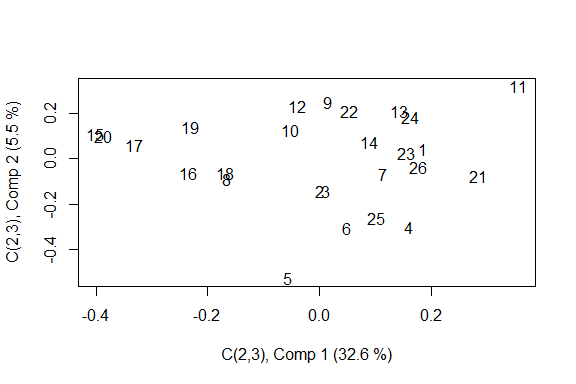

```r
# Score plot for local (2,3) components
plot(scores(pot.po.man,3), comps=1:2, labels="names")
```

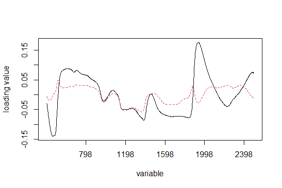

```r
# Corresponding loadings
plot(loadings(pot.po.man,3), comps=1:2, labels="names")
```

# Response Oriented Sequential Alternation - ROSA

The following example uses the *potato* data to showcase some of the functions available for ROSA analyses.

## Modelling

```r
# Model all eight potato blocks with ROSA
ros.pot <- rosa(Sensory ~ ., data = potato1, ncomp = 10, validation = "CV", segments = 5)
print(ros.pot)
```

```
#> Response Orinented Sequential Alternation , fitted with the CPPLS algorithm.
#> Cross-validated using 5 random segments.
#> Call:
#> rosa(formula = Sensory ~ ., ncomp = 10, data = potato1, validation = "CV",     segments = 5)
```

```r
summary(ros.pot)
```

```
#> Data:    X dimension: 26 3946
#>  Y dimension: 26 1
#> Fit method:
#> Number of components considered: 10
#>
#> VALIDATION: RMSEP
#> Cross-validated using 5 random segments.
#>        (Intercept)  1 comps  2 comps  3 comps  4 comps  5 comps  6 comps
#> CV           1.778   0.9748   0.8507   0.8495   0.7293   0.8953   1.0141
#> adjCV        1.778   0.9490   0.8289   0.8215   0.7156   0.8664   0.9742
#>        7 comps  8 comps  9 comps  10 comps
#> CV       1.155    1.391    1.539     1.936
#> adjCV    1.107    1.309    1.435     1.776
#>
#> TRAINING: % variance explained
#>          1 comps  2 comps  3 comps  4 comps  5 comps  6 comps  7 comps  8 comps
#> X          27.82    72.05    82.50    83.10    84.88    87.09    87.24    88.46
#> Sensory    76.53    83.36    84.21    87.91    88.06    88.18    88.17    88.47
#>          9 comps  10 comps
#> X          91.18     92.81
#> Sensory    88.78     88.78
```

## Loadings

Extract loadings (not used further) and plot two first vectors of loadings.

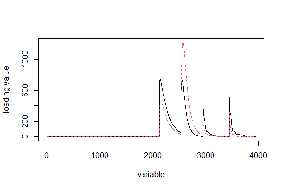

```r
loads <- loadings(ros.pot)
loadingplot(ros.pot, comps = 1:2)
```

## Scores

Extract scores (not used further) and plot two first vectors of scores.

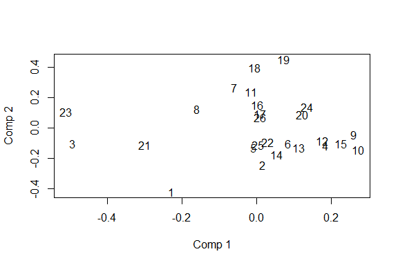

```r
sco <- scores(ros.pot)
scoreplot(ros.pot, comps = 1:2, labels = "names")
```

## Prediction

A three block model is fitted using a single response, 5 components and a subset of the data. The remaining data are used as test set for prediction.

```r
# Model 20 first objects of three potato blocks
rosT <- rosa(Sensory ~ ., data = potato1[c(1:3,9)], ncomp = 5, subset = 1:20)
testset <- potato1[-(1:20),]; # testset$Sensory <- NULL
predict(rosT, testset, comps=2)
```

```
#>      Sensory
#> 21 2.2151098
#> 22 1.5123048
#> 23 2.3008727
#> 24 1.2001610
#> 25 0.8899352
#> 26 1.2181709
```

## Validation

Compute validation statistics; explained variance - R$^2$ and Root Mean Squared Error - RMSE(P/CV).

```r
# Cross-validation
R2(ros.pot)
```

```
#> (Intercept)      1 comps      2 comps      3 comps      4 comps      5 comps
#>     -0.0816       0.6747       0.7523       0.7530       0.8179       0.7257
#>     6 comps      7 comps      8 comps      9 comps     10 comps
#>      0.6480       0.5431       0.3382       0.1892      -0.2825
```

```r
# Training
R2(ros.pot, 'train')
```

```
#> (Intercept)      1 comps      2 comps      3 comps      4 comps      5 comps
#>      0.0000       0.7653       0.8336       0.8421       0.8791       0.8806
#>     6 comps      7 comps      8 comps      9 comps     10 comps
#>      0.8818       0.8817       0.8847       0.8878       0.8878
```

```r
# Test data
R2(rosT, 'test', newdata = testset)
```

```
#> (Intercept)      1 comps      2 comps      3 comps      4 comps      5 comps
#>     -0.1609       0.3158       0.3289       0.4673       0.4634       0.4574
```

```r
# Cross-validation
RMSEP(ros.pot)
```

```
#>        (Intercept)  1 comps  2 comps  3 comps  4 comps  5 comps  6 comps
#> CV           1.778   0.9748   0.8507   0.8495   0.7293   0.8953   1.0141
#> adjCV        1.778   0.9490   0.8289   0.8215   0.7156   0.8664   0.9742
#>        7 comps  8 comps  9 comps  10 comps
#> CV       1.155    1.391    1.539     1.936
#> adjCV    1.107    1.309    1.435     1.776
```

```r
# Training
RMSEP(ros.pot, 'train')
```

```
#> (Intercept)      1 comps      2 comps      3 comps      4 comps      5 comps
#>      1.7093       0.8280       0.6972       0.6792       0.5944       0.5906
#>     6 comps      7 comps      8 comps      9 comps     10 comps
#>      0.5877       0.5879       0.5805       0.5726       0.5726
```

```r
# Test data
RMSEP(rosT, newdata = testset)
```

```
#> (Intercept)      1 comps      2 comps      3 comps      4 comps      5 comps
#>       2.435        1.869        1.851        1.649        1.655        1.664
```

## Image plots

Plots for evaluation of the block selection process in ROSA.

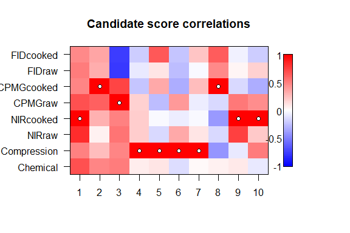

```r
# Correlation to winning scores
image(ros.pot)
```

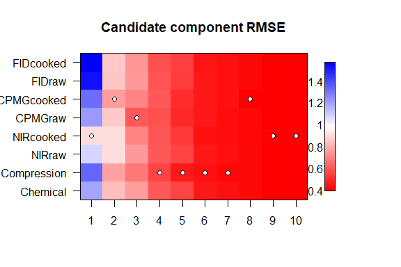

```r
# Residual response given candidate scores
image(ros.pot, "residual")
```

# Multiblock Redundancy Analysis - mbRDA

The following example uses the *potato* data to showcase some of the functions available for mbRDA analyses.

## Modelling

This implementation uses a wrapper for the *mbpcaiv* function in the *ade4* package to perform mbRDA. A multi-response 5 component model is fitted.

```r
# Convert data.frame with AsIs objects to list of matrices
potatoList <- lapply(potato, unclass)

# Perform mbRDA with two blocks explaining sensory attributes
mbr <- mbrda(potatoList[c('Chemical','Compression')], potatoList[['Sensory']], ncomp = 5)
print(mbr)
```

```
#> Multiblock RDA
#>
#> Call:
#> mbrda(X = potatoList[c("Chemical", "Compression")], Y = potatoList[["Sensory"]],     ncomp = 5)
```

## Loadings and scores

The *mbpcaiv* wrapper extracts key elements for inspection using the same format as the rest of this package. The full fitted *mbpcaiv* object is also available, e.g. through *mbr$mbpcaivObject*.

```r
# Extract and view loadings
lo_mbr <- loadings(mbr)
print(head(lo_mbr))
```

[output not shown]

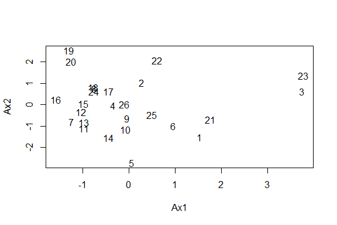

```r
# Plot scores
scoreplot(mbr, labels = "names")
```